# SBP scaling

Systolic blood pressure has two GWASs in EAS from BBJ. How comparable are these units, and also compared against UKBB European results

```r
library(TwoSampleMR)
library(dplyr)
library(ieugwasr)
library(readr)
library(ggplot2)
```

Read in list of cross-ancestry SNPs to use for SBP

```r
snps <- read.csv("~/Downloads/bbj_new_sumstat.csv")
head(snps)
```

|  | chr | position | beta | se | p | n | id | rsid | ea | nea | eaf | trait | original_rsid | zsum | units | samplesize | method |
| --- | --- | --- | --- | --- | --- | --- | --- | --- | --- | --- | --- | --- | --- | --- | --- | --- | --- |
| 1 | 1 | 1689164 | 0.3110 | 0.0314 | 4.48642e-23 | 688978 | ieu-b-38 | rs2235536 | T | C | 0.4232 | systolic blood pressure | rs7796 | 1.691012 | NA | 757601 | maxz |
| 2 | 1 | 2141985 | -0.1791 | 0.0320 | 2.07200e-08 | 688565 | ieu-b-38 | rs1105269 | A | C | 0.3890 | systolic blood pressure | rs263532 | -1.885087 | NA | 757601 | maxz |
| 3 | 1 | 3327549 | 0.2194 | 0.0324 | 1.33291e-11 | 683365 | ieu-b-38 | rs1106270 | G | A | 0.3754 | systolic blood pressure | rs2493296 | 1.362620 | NA | 757601 | maxz |
| 4 | 1 | 10796547 | 0.5131 | 0.0324 | 1.38612e-56 | 705710 | ieu-b-38 | rs17035646 | A | G | 0.3412 | systolic blood pressure | rs488834 | 2.000000 | NA | 757601 | maxz |
| 5 | 1 | 11910677 | -0.4697 | 0.0311 | 1.54703e-51 | 715739 | ieu-b-38 | rs632793 | G | A | 0.3962 | systolic blood pressure | rs6699618 | -1.679340 | NA | 757601 | maxz |
| 6 | 1 | 15792426 | -0.2835 | 0.0383 | 1.38612e-13 | 712350 | ieu-b-38 | rs2901964 | G | C | 0.1991 | systolic blood pressure | rs75461554 | -1.882752 | NA | 757601 | maxz |

These are the two BBJ SBP GWASs

```r
gwasinfo(c("ieu-b-5075", "bbj-a-52")) %>% glimpse()
```

```
Using access token. For info on how this is used see logging_info()
ℹ The googleAuthR package is using a cached token for explodecomputer@gmail.com.
```

```
Rows: 2
Columns: 19
$ id          <chr> "ieu-b-5075", "bbj-a-52"
$ trait       <chr> "Systolic blood pressure", "Systolic blood pressure"
$ unit        <chr> "mmHg", "NA"
$ sample_size <int> 145505, 136597
$ nsnp        <int> 13230376, 6108953
$ sex         <chr> "Males and Females", "Males and Females"
$ category    <chr> "Risk factor", "Continuous"
$ author      <chr> "Sakaue et al.", "Ishigaki K"
$ note        <lgl> NA, NA
$ group_name  <chr> "public", "public"
$ mr          <int> 1, 1
$ ontology    <lgl> NA, NA
$ build       <chr> "HG19/GRCh37", "HG19/GRCh37"
$ subcategory <chr> "Blood pressure", "NA"
$ year        <int> 2021, 2019
$ consortium  <lgl> NA, NA
$ population  <chr> "East Asian", "East Asian"
$ pmid        <int> 34594039, 29403010
$ priority    <int> NA, 0
```

Relationship between these two BBJ datasets

```r
r <- mr(dat)
```

```
Analysing 'ieu-b-5075' on 'bbj-a-52'
```

```r
r
```

| id.exposure | id.outcome | outcome | exposure | method | nsnp | b | se | pval |
| --- | --- | --- | --- | --- | --- | --- | --- | --- |
| ieu-b-5075 | bbj-a-52 | Systolic blood pressure \|\| id:bbj-a-52 | Systolic blood pressure \|\| id:ieu-b-5075 | MR Egger | 347 | 0.265167947 | 0.02874704 | 2.918879e-18 |
| ieu-b-5075 | bbj-a-52 | Systolic blood pressure \|\| id:bbj-a-52 | Systolic blood pressure \|\| id:ieu-b-5075 | Weighted median | 347 | 0.089993708 | 0.30113974 | 7.650593e-01 |
| ieu-b-5075 | bbj-a-52 | Systolic blood pressure \|\| id:bbj-a-52 | Systolic blood pressure \|\| id:ieu-b-5075 | Inverse variance weighted | 347 | 0.623422573 | 0.02893931 | 6.236810e-103 |
| ieu-b-5075 | bbj-a-52 | Systolic blood pressure \|\| id:bbj-a-52 | Systolic blood pressure \|\| id:ieu-b-5075 | Simple mode | 347 | 1.088920436 | 0.07644490 | 1.489625e-36 |
| ieu-b-5075 | bbj-a-52 | Systolic blood pressure \|\| id:bbj-a-52 | Systolic blood pressure \|\| id:ieu-b-5075 | Weighted mode | 347 | 0.000318176 | 0.03299226 | 9.923109e-01 |

```
$`ieu-b-5075.bbj-a-52`

attr(,"split_type")
[1] "data.frame"
attr(,"split_labels")
```

| id.exposure | id.outcome |
| --- | --- |
| ieu-b-5075 | bbj-a-52 |

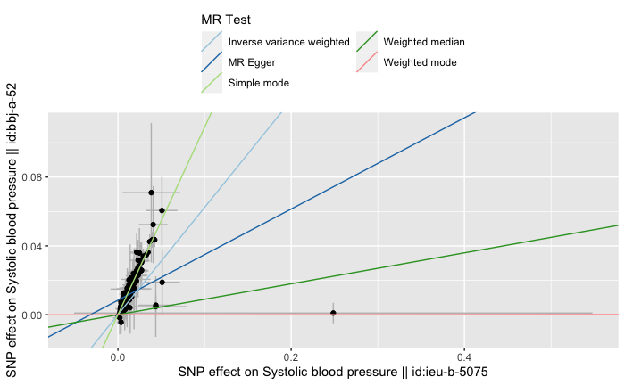

```r
mr_scatter_plot(r, dat)
```

The simple mode gives a very good indication here that the units are the same in the two studies. However, there is a massive outlier introduced in the more recent one, which distorts the results for the other datasets

Relationship between BBJ and UKBB-EUR

```r
c <- extract_outcome_data(snps$rsid, "ukb-b-20175")
```

```
Extracting data for 402 SNP(s) from 1 GWAS(s)
Using access token. For info on how this is used see logging_info()
ℹ The googleAuthR package is using a cached token for explodecomputer@gmail.com.
Finding proxies for 24 SNPs in outcome ukb-b-20175
Extracting data for 24 SNP(s) from 1 GWAS(s)
```

```r
dat2 <- harmonise_data(a, c)
```

```
Harmonising Systolic blood pressure || id:ieu-b-5075 (ieu-b-5075) and Systolic blood pressure, automated reading || id:ukb-b-20175 (ukb-b-20175)
Removing the following SNPs for being palindromic with intermediate allele frequencies:
rs10033071, rs10260816, rs10863328, rs12665601, rs12889006, rs17714333, rs2024385, rs2129869, rs2401948, rs2530242, rs2652823, rs2797983, rs41317515, rs4997571, rs6029738, rs6606644, rs7463212, rs9855086
```

```r
res2 <- mr(dat2)
```

```
Analysing 'ieu-b-5075' on 'ukb-b-20175'
```

```r
res2
```

| id.exposure | id.outcome | outcome | exposure | method | nsnp | b | se | pval |
| --- | --- | --- | --- | --- | --- | --- | --- | --- |
| ieu-b-5075 | ukb-b-20175 | Systolic blood pressure, automated reading \|\| id:ukb-b-20175 | Systolic blood pressure \|\| id:ieu-b-5075 | MR Egger | 360 | 0.001477355 | 0.006187045 | 0.8114112297 |
| ieu-b-5075 | ukb-b-20175 | Systolic blood pressure, automated reading \|\| id:ukb-b-20175 | Systolic blood pressure \|\| id:ieu-b-5075 | Weighted median | 360 | 0.007423450 | 0.024398282 | 0.7609289277 |
| ieu-b-5075 | ukb-b-20175 | Systolic blood pressure, automated reading \|\| id:ukb-b-20175 | Systolic blood pressure \|\| id:ieu-b-5075 | Inverse variance weighted | 360 | 0.054101780 | 0.011484534 | 0.0000024670 |
| ieu-b-5075 | ukb-b-20175 | Systolic blood pressure, automated reading \|\| id:ukb-b-20175 | Systolic blood pressure \|\| id:ieu-b-5075 | Simple mode | 360 | 0.916185367 | 0.235460656 | 0.0001189649 |
| ieu-b-5075 | ukb-b-20175 | Systolic blood pressure, automated reading \|\| id:ukb-b-20175 | Systolic blood pressure \|\| id:ieu-b-5075 | Weighted mode | 360 | 0.018293824 | 0.237315133 | 0.9385975731 |

```
$`ieu-b-5075.ukb-b-20175`

attr(,"split_type")
[1] "data.frame"
attr(,"split_labels")
```

| id.exposure | id.outcome |
| --- | --- |
| ieu-b-5075 | ukb-b-20175 |

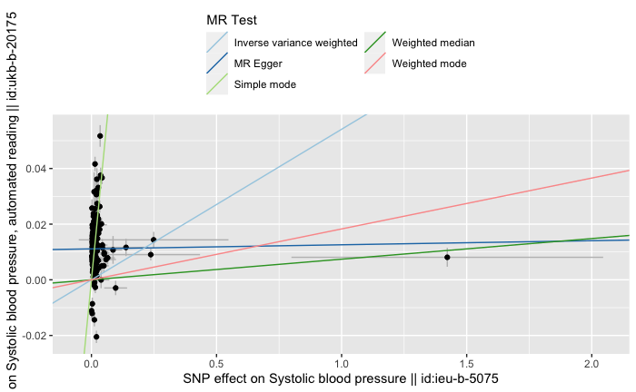

```r
mr_scatter_plot(res2, dat2)
```

Similar situation here where the simple mode gets it right, and the estimate suggests the scales are the same. But these massive outliers pose a problem

```r
c <- extract_outcome_data(snps$rsid, "ukb-b-20175")
```

```
Extracting data for 402 SNP(s) from 1 GWAS(s)
Using access token. For info on how this is used see logging_info()
ℹ The googleAuthR package is using a cached token for explodecomputer@gmail.com.
Finding proxies for 24 SNPs in outcome ukb-b-20175
Extracting data for 24 SNP(s) from 1 GWAS(s)
```

```r
dat3 <- harmonise_data(b%>% convert_outcome_to_exposure(), c)
```

```
Harmonising Systolic blood pressure || id:bbj-a-52 (bbj-a-52) and Systolic blood pressure, automated reading || id:ukb-b-20175 (ukb-b-20175)
Removing the following SNPs for being palindromic with intermediate allele frequencies:
rs10033071, rs10260816, rs10863328, rs12889006, rs17714333, rs2024385, rs2129869, rs2530242, rs2652823, rs2797983, rs41317515, rs4997571, rs6029738, rs6606644, rs7463212, rs9855086
```

```r
res3 <- mr(dat3)
```

```
Analysing 'bbj-a-52' on 'ukb-b-20175'
```

```r
res3
```

| id.exposure | id.outcome | outcome | exposure | method | nsnp | b | se | pval |
| --- | --- | --- | --- | --- | --- | --- | --- | --- |
| bbj-a-52 | ukb-b-20175 | Systolic blood pressure, automated reading \|\| id:ukb-b-20175 | Systolic blood pressure \|\| id:bbj-a-52 | MR Egger | 339 | 0.2370438 | 0.04184649 | 3.161884e-08 |
| bbj-a-52 | ukb-b-20175 | Systolic blood pressure, automated reading \|\| id:ukb-b-20175 | Systolic blood pressure \|\| id:bbj-a-52 | Weighted median | 339 | 0.5136163 | 0.03592413 | 2.276230e-46 |
| bbj-a-52 | ukb-b-20175 | Systolic blood pressure, automated reading \|\| id:ukb-b-20175 | Systolic blood pressure \|\| id:bbj-a-52 | Inverse variance weighted | 339 | 0.7059109 | 0.02950607 | 1.713007e-126 |
| bbj-a-52 | ukb-b-20175 | Systolic blood pressure, automated reading \|\| id:ukb-b-20175 | Systolic blood pressure \|\| id:bbj-a-52 | Simple mode | 339 | 0.8837763 | 0.13938618 | 7.334856e-10 |
| bbj-a-52 | ukb-b-20175 | Systolic blood pressure, automated reading \|\| id:ukb-b-20175 | Systolic blood pressure \|\| id:bbj-a-52 | Weighted mode | 339 | 0.5574171 | 0.13961855 | 8.026142e-05 |

```
$`bbj-a-52.ukb-b-20175`

attr(,"split_type")
[1] "data.frame"
attr(,"split_labels")
```

| id.exposure | id.outcome |
| --- | --- |
| bbj-a-52 | ukb-b-20175 |

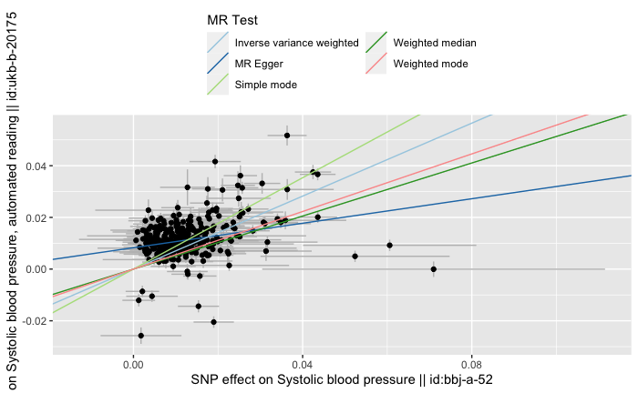

```r
mr_scatter_plot(res3, dat3)
```

Perform MR of SBP

```r
res <- mr(dat, method_list=c("mr_ivw"))
```

```
Analysing 'bbj-a-52' on 'bbj-a-159'
Analysing 'bbj-a-52' on 'ebi-a-GCST005195'
Analysing 'ieu-b-5075' on 'bbj-a-159'
Analysing 'ieu-b-5075' on 'ebi-a-GCST005195'
Analysing 'ukb-b-20175' on 'bbj-a-159'
Analysing 'ukb-b-20175' on 'ebi-a-GCST005195'
```

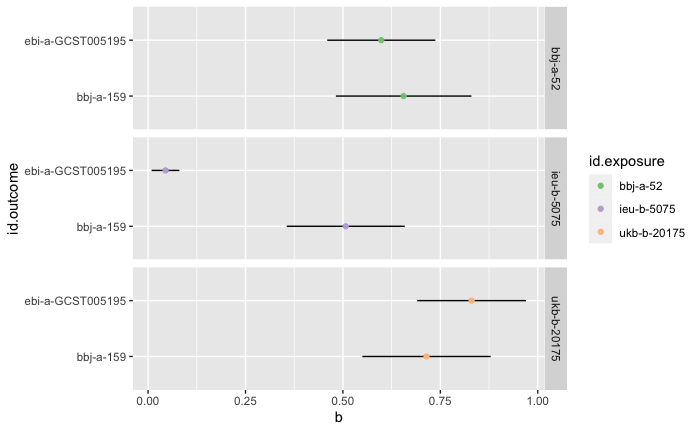

```r
ggplot(res, aes(x=b, y=id.outcome)) +
  geom_errorbarh(aes(xmin=b - 1.96*se, xmax=b+1.96*se), height=0) +
  geom_point(aes(colour=id.exposure)) +
  facet_grid(id.exposure ~ .) + scale_colour_brewer(type="qual")
```

```r
d <- gendat(snps$rsid, "ieu-b-5075", "ebi-a-GCST005195")
```

[output not shown]

```r
dr <- d %>% mr()
```

```
Analysing 'ieu-b-5075' on 'ebi-a-GCST005195'
```

```r
dr
```

| id.exposure | id.outcome | outcome | exposure | method | nsnp | b | se | pval |
| --- | --- | --- | --- | --- | --- | --- | --- | --- |
| ieu-b-5075 | ebi-a-GCST005195 | Coronary artery disease \|\| id:ebi-a-GCST005195 | Systolic blood pressure \|\| id:ieu-b-5075 | MR Egger | 322 | 0.0003669403 | 0.01647487 | 0.982244288 |
| ieu-b-5075 | ebi-a-GCST005195 | Coronary artery disease \|\| id:ebi-a-GCST005195 | Systolic blood pressure \|\| id:ieu-b-5075 | Weighted median | 322 | 0.0113348558 | 0.04097297 | 0.782054800 |
| ieu-b-5075 | ebi-a-GCST005195 | Coronary artery disease \|\| id:ebi-a-GCST005195 | Systolic blood pressure \|\| id:ieu-b-5075 | Inverse variance weighted | 322 | 0.0447132253 | 0.01821706 | 0.014109257 |
| ieu-b-5075 | ebi-a-GCST005195 | Coronary artery disease \|\| id:ebi-a-GCST005195 | Systolic blood pressure \|\| id:ieu-b-5075 | Simple mode | 322 | 0.3257990642 | 0.12370546 | 0.008855863 |
| ieu-b-5075 | ebi-a-GCST005195 | Coronary artery disease \|\| id:ebi-a-GCST005195 | Systolic blood pressure \|\| id:ieu-b-5075 | Weighted mode | 322 | 0.0076361691 | 0.03998717 | 0.848673378 |

```
$`ieu-b-5075.ebi-a-GCST005195`

attr(,"split_type")
[1] "data.frame"
attr(,"split_labels")
```

| id.exposure | id.outcome |
| --- | --- |
| ieu-b-5075 | ebi-a-GCST005195 |

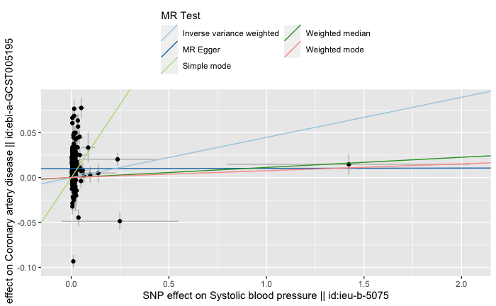

```r
mr_scatter_plot(dr, d)
```

```r
d <- gendat(snps$rsid, "ieu-b-5075", "bbj-a-159")
```

```
Extracting data for 402 SNP(s) from 1 GWAS(s)
Using access token. For info on how this is used see logging_info()
ℹ The googleAuthR package is using a cached token for explodecomputer@gmail.com.
Warning in .fun(piece, ...) :
  Duplicated SNPs present in exposure data for phenotype 'Systolic blood pressure || id:ieu-b-5075. Just keeping the first instance:
rs1488299392
Extracting data for 402 SNP(s) from 1 GWAS(s)
Using access token. For info on how this is used see logging_info()
ℹ The googleAuthR package is using a cached token for explodecomputer@gmail.com.
Finding proxies for 18 SNPs in outcome bbj-a-159
Extracting data for 18 SNP(s) from 1 GWAS(s)
Harmonising Systolic blood pressure || id:ieu-b-5075 (ieu-b-5075) and Coronary artery disease || id:bbj-a-159 (bbj-a-159)
Removing the following SNPs for being palindromic with intermediate allele frequencies:
rs10033071, rs10863328, rs12665601, rs2024385, rs2129869, rs2530242, rs41317515, rs6029738, rs752667104
```

```r
dr <- d %>% mr()
```

```
Analysing 'ieu-b-5075' on 'bbj-a-159'
```

```r
dr
```

| id.exposure | id.outcome | outcome | exposure | method | nsnp | b | se | pval |
| --- | --- | --- | --- | --- | --- | --- | --- | --- |
| ieu-b-5075 | bbj-a-159 | Coronary artery disease \|\| id:bbj-a-159 | Systolic blood pressure \|\| id:ieu-b-5075 | MR Egger | 380 | 0.18695844 | 0.11422898 | 1.025257e-01 |
| ieu-b-5075 | bbj-a-159 | Coronary artery disease \|\| id:bbj-a-159 | Systolic blood pressure \|\| id:ieu-b-5075 | Weighted median | 380 | 0.07331615 | 0.15758546 | 6.417546e-01 |
| ieu-b-5075 | bbj-a-159 | Coronary artery disease \|\| id:bbj-a-159 | Systolic blood pressure \|\| id:ieu-b-5075 | Inverse variance weighted | 380 | 0.50723636 | 0.07723053 | 5.105654e-11 |
| ieu-b-5075 | bbj-a-159 | Coronary artery disease \|\| id:bbj-a-159 | Systolic blood pressure \|\| id:ieu-b-5075 | Simple mode | 380 | 0.87978692 | 0.29279930 | 2.834757e-03 |
| ieu-b-5075 | bbj-a-159 | Coronary artery disease \|\| id:bbj-a-159 | Systolic blood pressure \|\| id:ieu-b-5075 | Weighted mode | 380 | 0.15585649 | 0.16291694 | 3.393476e-01 |

```
$`ieu-b-5075.bbj-a-159`

attr(,"split_type")
[1] "data.frame"
attr(,"split_labels")
```

| id.exposure | id.outcome |
| --- | --- |
| ieu-b-5075 | bbj-a-159 |

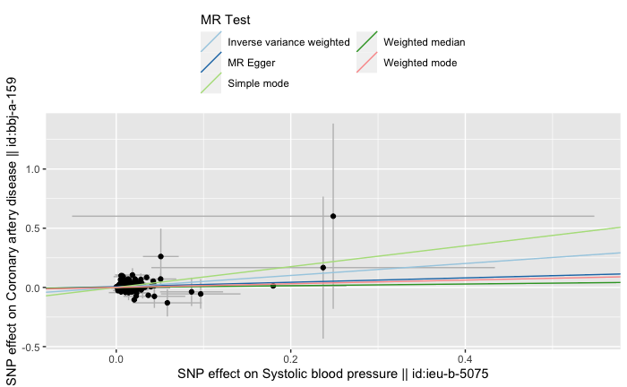

```r
mr_scatter_plot(dr, d)
```

That outlier SNP is just not present in BBJ’s CAD.

Check concordance of outcome datasets (note that don’t have SNPs selected for multiple ancestries here)

```r
do1 <- make_dat("ebi-a-GCST005195", "bbj-a-159")
```

```
Extracting data for 75 SNP(s) from 1 GWAS(s)
Finding proxies for 23 SNPs in outcome bbj-a-159
Extracting data for 23 SNP(s) from 1 GWAS(s)
Harmonising Coronary artery disease || id:ebi-a-GCST005195 (ebi-a-GCST005195) and Coronary artery disease || id:bbj-a-159 (bbj-a-159)
```

```r
r1 <- mr(do1)
```

```
Analysing 'ebi-a-GCST005195' on 'bbj-a-159'
```

```r
r1
```

| id.exposure | id.outcome | outcome | exposure | method | nsnp | b | se | pval |
| --- | --- | --- | --- | --- | --- | --- | --- | --- |
| ebi-a-GCST005195 | bbj-a-159 | Coronary artery disease \|\| id:bbj-a-159 | Coronary artery disease \|\| id:ebi-a-GCST005195 | MR Egger | 61 | 0.14116674 | 0.09437780 | 1.400459e-01 |
| ebi-a-GCST005195 | bbj-a-159 | Coronary artery disease \|\| id:bbj-a-159 | Coronary artery disease \|\| id:ebi-a-GCST005195 | Weighted median | 61 | 0.12505061 | 0.07693171 | 1.040613e-01 |
| ebi-a-GCST005195 | bbj-a-159 | Coronary artery disease \|\| id:bbj-a-159 | Coronary artery disease \|\| id:ebi-a-GCST005195 | Inverse variance weighted | 61 | 0.52914664 | 0.06682441 | 2.404633e-15 |
| ebi-a-GCST005195 | bbj-a-159 | Coronary artery disease \|\| id:bbj-a-159 | Coronary artery disease \|\| id:ebi-a-GCST005195 | Simple mode | 61 | 0.94156669 | 0.11569449 | 2.846300e-11 |
| ebi-a-GCST005195 | bbj-a-159 | Coronary artery disease \|\| id:bbj-a-159 | Coronary artery disease \|\| id:ebi-a-GCST005195 | Weighted mode | 61 | -0.02363188 | 0.03610546 | 5.152757e-01 |

```
$`ebi-a-GCST005195.bbj-a-159`

attr(,"split_type")
[1] "data.frame"
attr(,"split_labels")
```

| id.exposure | id.outcome |
| --- | --- |
| ebi-a-GCST005195 | bbj-a-159 |

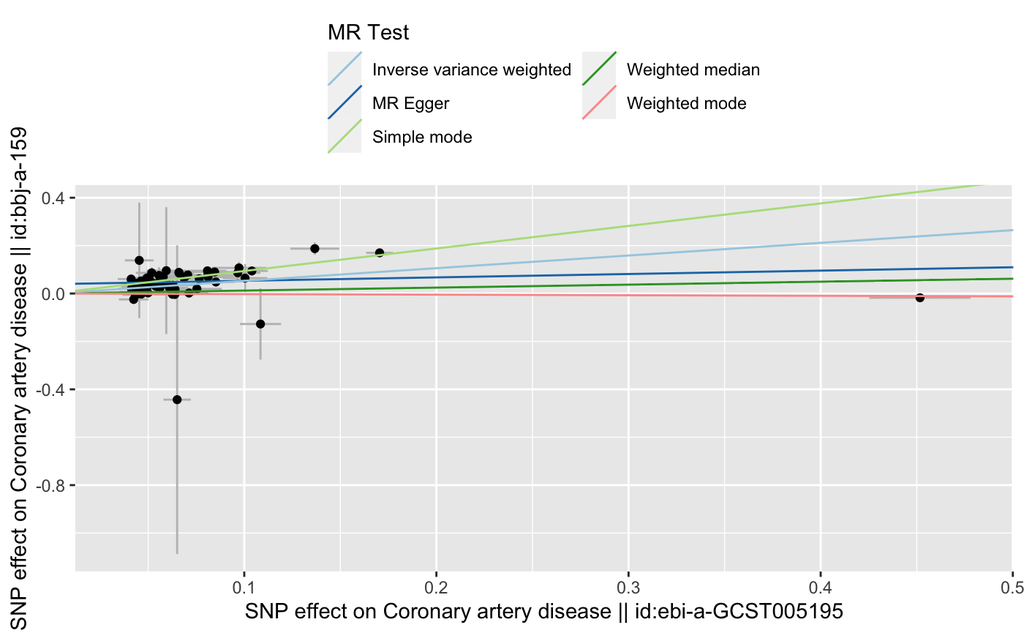

```r
mr_scatter_plot(r1, do1)
```

```r
do2 <- make_dat("bbj-a-159", "ebi-a-GCST005195")
r2 <- mr(do2)
r2
mr_scatter_plot(r2, do2)
```

[output not shown]

**Use the better powered GWAS as the exposure to reduce regression dilution bias**

```r
adjx <- gendat(snps$rsid, "ukb-b-20175", "bbj-a-52")
```

```
Extracting data for 402 SNP(s) from 1 GWAS(s)
Finding proxies for 24 SNPs in outcome ukb-b-20175
Extracting data for 24 SNP(s) from 1 GWAS(s)
Extracting data for 402 SNP(s) from 1 GWAS(s)
Finding proxies for 53 SNPs in outcome bbj-a-52
Extracting data for 53 SNP(s) from 1 GWAS(s)
Harmonising Systolic blood pressure, automated reading || id:ukb-b-20175 (ukb-b-20175) and Systolic blood pressure || id:bbj-a-52 (bbj-a-52)
Removing the following SNPs for being palindromic with intermediate allele frequencies:
rs10033071, rs10260816, rs10863328, rs12889006, rs17714333, rs2024385, rs2129869, rs2530242, rs2652823, rs2797983, rs41317515, rs4997571, rs6029738, rs6606644, rs7463212, rs9855086
```

```r
r <- mr(adjx)
```

```
Analysing 'ukb-b-20175' on 'bbj-a-52'
```

```r
r
```

| id.exposure | id.outcome | outcome | exposure | method | nsnp | b | se | pval |
| --- | --- | --- | --- | --- | --- | --- | --- | --- |
| ukb-b-20175 | bbj-a-52 | Systolic blood pressure \|\| id:bbj-a-52 | Systolic blood pressure, automated reading \|\| id:ukb-b-20175 | MR Egger | 339 | 0.6236360 | 0.05638755 | 1.823578e-24 |
| ukb-b-20175 | bbj-a-52 | Systolic blood pressure \|\| id:bbj-a-52 | Systolic blood pressure, automated reading \|\| id:ukb-b-20175 | Weighted median | 339 | 0.7033469 | 0.03388122 | 1.012506e-95 |
| ukb-b-20175 | bbj-a-52 | Systolic blood pressure \|\| id:bbj-a-52 | Systolic blood pressure, automated reading \|\| id:ukb-b-20175 | Inverse variance weighted | 339 | 0.8187545 | 0.02647529 | 5.470525e-210 |
| ukb-b-20175 | bbj-a-52 | Systolic blood pressure \|\| id:bbj-a-52 | Systolic blood pressure, automated reading \|\| id:ukb-b-20175 | Simple mode | 339 | -0.3773033 | 28.16266176 | 9.893187e-01 |
| ukb-b-20175 | bbj-a-52 | Systolic blood pressure \|\| id:bbj-a-52 | Systolic blood pressure, automated reading \|\| id:ukb-b-20175 | Weighted mode | 339 | -0.3773033 | 29.57901154 | 9.898302e-01 |

```
$`ukb-b-20175.bbj-a-52`

attr(,"split_type")
[1] "data.frame"
attr(,"split_labels")
```

| id.exposure | id.outcome |
| --- | --- |
| ukb-b-20175 | bbj-a-52 |

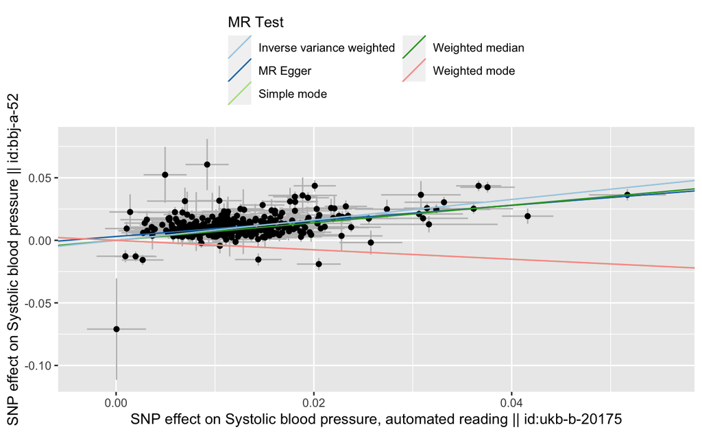

```r
mr_scatter_plot(r, adjx)
```

The effect appears to be quite convincingly attenuated by ~20% in BBJ